# SQL Missing Data

## How does the database represents missing data

- A noted earlier, all database system have the concept of a `NULL` value; Something which is missing and nothing is known about it.
- In DB Browser we can choose how we want `NULLs` in a table to be displayed.
- When we had our initial look at DB Browser, we used the `View | Preference` option to change the background colour of cells in a table which has a `NULL` values as red.
- The example below is a version of the SN7577 table with most of the columns removed and some NULL values introduced in the `numage` column.

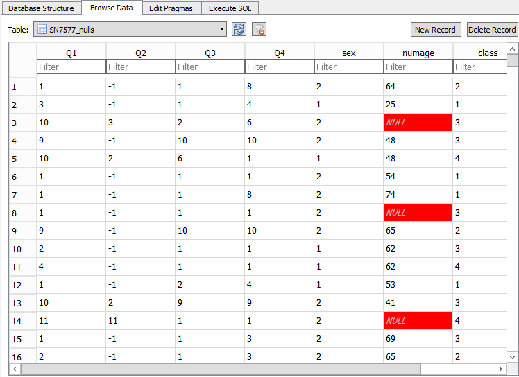

image 1

- If you type `=NULL` in the filter box for `numage`, only the rows with `NULL` in `numage` will be displayed.
- You can get the same results using the following query:

```sql
SELECT * from
    SN7577_nulls
WHERE numage is NULL;
```

- This table was created from a `csv` file which looks like this

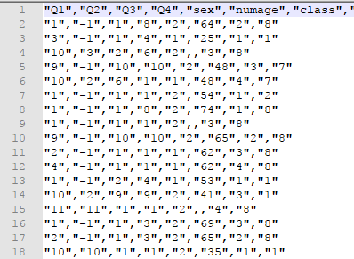

image2

- The line numbers on the left are from the text editor and are not part of the data.
- You can see that in `lines 4, 9 and 15` there are consequetive `, ,`s where the numage values should be. These values are missing from the data.

### Other representations of missing data

- The `SN7577_nulls` table was specially created to demonstrate how NULLs appear in DB Browser.
- The proper `SN7577` table does not contain any missing values in the sense of having consequetive `,,`s.
- This is because the SN7577 data is provided by the `UKDS (UK Data Service)` whose role in part is to clean datasets before making them publicly available.
- However the data provided to them, could well have missing data.
- In the case of the `SN7577` dataset this is typically dealt with by substituting the missing value with a value of `-1`.
- This is explained in the provided `data dictionary` for the `SN7577` dataset.
- An extract for `Q2` is shown below.

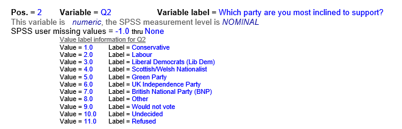

image

- You can see from the extract of the `SN7577_nulls` file above that there are several `-1` values in the `Q2` field indicating the original data had no value, therefore interpreted as a `NULL` value for specific rows in `Q2`.
- This is very different from rows which have a value of `11` for column `Q2` (3rd row from bottom).
- The `value 11` means that the participant `refused` to provide an answer.
- The refusal may not tell you which party they are inclined to vote for, but it does convey some kind of information.
- **A `NULL` value tells you nothing.**
- Different statistical packages like `SPSS` or `Stata` have their own way of representing `NULL values` such as `-99` or `-999`.
- You need to be aware of how NULL values in your dataset are being represented.